# DS400: Assignment III (Python)

##### Mohamed Elsherif (Student ID: 6378374)

##### January 07, 2025

## Part II: Data Inspection

```python
# Necessary Library Setup
import os
from pathlib import Path
import pandas as pd
import matplotlib.pyplot as plt
import seaborn as sns

## Machine Learning Libraries
from sklearn.model_selection import train_test_split
from sklearn.preprocessing import StandardScaler
from sklearn.neighbors import KNeighborsClassifier
from sklearn.ensemble import RandomForestClassifier
from sklearn.metrics import accuracy_score, classification_report, confusion_matrix
```

```python
# Set working directory to location where this notebook is located
os.chdir(Path().resolve())

# Verify
print("My Current Working Directory: ", os.getcwd())
```

```
My Current Working Directory:  /Users/dr.elsherif/Downloads/Assignment03
```

2. Load the dataset and inspect the first few rows. What are the column names and their data types? Are there any missing values? If so, how many are there in each column?

```python
# Load the dataset
WhiteWine = pd.read_csv("./data/winequality-white.csv", delimiter=";")

# Inspect dataset
WhiteWine.head()

# Get the column names and their data types
print(WhiteWine.dtypes)

# Check missing values and count them in each column
print(WhiteWine.isna().sum())
```

```
fixed acidity           float64
volatile acidity        float64
citric acid             float64
residual sugar          float64
chlorides               float64
free sulfur dioxide     float64
total sulfur dioxide    float64
density                 float64
pH                      float64
sulphates               float64
alcohol                 float64
quality                   int64
dtype: object
fixed acidity           0
volatile acidity        0
citric acid             0
residual sugar          0
chlorides               0
free sulfur dioxide     0
total sulfur dioxide    0
density                 0
pH                      0
sulphates               0
alcohol                 0
quality                 0
dtype: int64
```

3. Create a plot that shows the distribution of the target variable quality. Include the number of cases for each quality rating at the top of each bar. What can you infer from the plot?

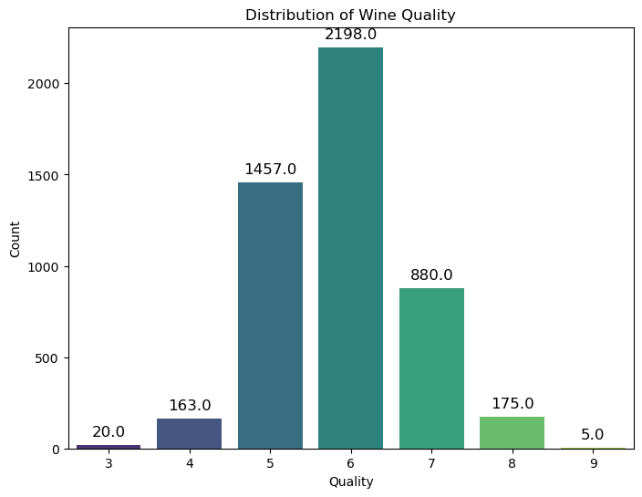

```python
# Plot the distribution of the 'quality' column
plt.figure(figsize=(8,6))
sns.countplot(data=WhiteWine, x='quality', palette='viridis')

for p in plt.gca().patches:
    plt.gca().annotate(f'{p.get_height()}',
                       (p.get_x() + p.get_width() / 2., p.get_height()),
                       ha='center', va='center',
                       fontsize=12, color='black',
                       xytext=(0, 10), textcoords='offset points')

plt.xlabel('Quality')
plt.ylabel('Count')
plt.title('Distribution of Wine Quality')
plt.xticks()
plt.show()
```

**From the plot, I infer the presence of the following:**

-**Skewed Distribution:** The wine quality scores are not evenly distributed. Most wines are rated between 5 and 7, with 6 being the most common rating. Very few wines have a quality score of 3 or 9, suggesting a lack of extremely poor or excellent wines in the dataset.

-**Imbalanced Data:** There is imbalance in the quality ratings.

4. The dataset’s info file contains a note saying that “several of the attributes may be correlated.” Create a correlogram to visualize the correlation between the variables. What can you infer from the correlogram?

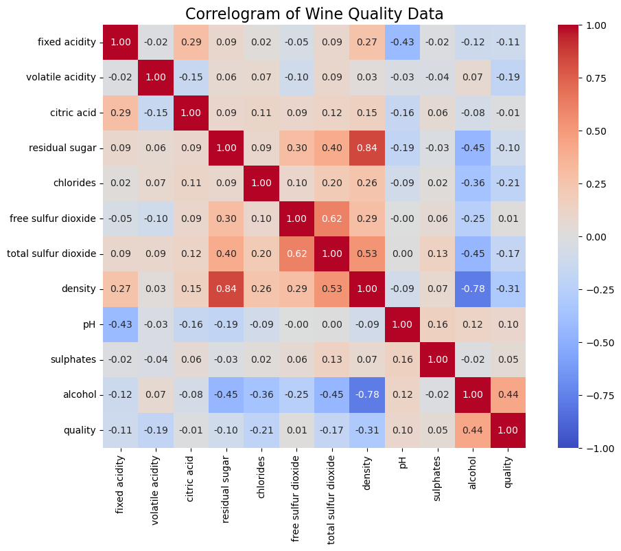

```python
# Calculate the correlation matrix
corr_matrix = WhiteWine.corr()

# Create correlogram
plt.figure(figsize=(12, 8))
sns.heatmap(corr_matrix, annot=True, fmt=".2f", cmap='coolwarm', vmin=-1, vmax=1, square=True)

plt.title('Correlogram of Wine Quality Data', fontsize=16)
plt.show()
```

**From the correlogram, I notice and can infer that:**

-There is strong positive correlation between residual sugar and density (0.84) which makes sense as higher sugar increases the density of the wine.

-These is high positive correlation between total sulfur dioxide and free sulfur dioxide (0.62), which are actually related properties.

-There is strong negative correlation between density and alcohol (-0.78).

It is improtant to note that these strong intercorrelations could suggest multicollinearity and may infact pose a challenge to any linear model.

## Part III: Data Preprocessing

5. Create a new column quality_cat that categorizes the quality of the wine into four categories: low, medium, high, and prestigious. The categories should be based on the following criteria: low for quality ratings below 5, medium for quality ratings of 5 and 6, high for quality ratings of 7 and 8, and prestigious for quality ratings above 8.

```python
# a function to categorize wine quality
def categorize_quality(quality):
    if quality < 5:
        return "low"
    elif quality in [5, 6]:
        return "medium"
    elif quality in [7, 8]:
        return "high"
    else:
        return "prestigious"

# create a new column 'quality_cat'
WhiteWine['quality_cat'] = WhiteWine['quality'].apply(categorize_quality)

# Verify
WhiteWine[['quality', 'quality_cat']].head()
```

|  | quality | quality_cat |
| --- | --- | --- |
| 0 | 6 | medium |
| 1 | 6 | medium |
| 2 | 6 | medium |
| 3 | 6 | medium |
| 4 | 6 | medium |

6. Split the dataset into a training and a test set. Use 70% of the data for training and 30% for testing.To make sure your results are reproducible, use 42 as seed.

```python
# Split dataset
train_set, test_set = train_test_split(WhiteWine, test_size=0.3, random_state=42)

# Verify
print(f"Training set size: {len(train_set)}")
print(f"Test set size: {len(test_set)}")
```

```
Training set size: 3428
Test set size: 1470
```

## Part IV: Machine Learning

7. Explain why logistic a regression is not a suitable model for this dataset.

**Logistic regression is not suitable for modeling this dataset because of:**

-**Multi-classes:** Logistic regression is designed for binary classification. This dataset has Multiclasses (Quality 3-9). Handling multiclasses may require other complex variants like multinomial or ordinal logistic regression.

-**Imbalanced Classes:** Given the observed class imbalance in the dataset as was shown in the bar plot above, logistic regression may produce biased predictions favoring the dominant class.

-**Multicollinearity:** The strong intercorrelations between some features (e.g., residual sugar and density) observed in the correlogram violate logistic regression assumptions.

8. Train a K-Nearest Neighbors model to predict the quality of the wine. You may need to prepare the data for use with the model. Make sure your training process is reproducible

```python
# Exclude the 'quality_cat' column for scaling and model input
X_train = train_set.drop(columns=['quality', 'quality_cat'])
y_train = train_set['quality']
X_test = test_set.drop(columns=['quality', 'quality_cat'])
y_test = test_set['quality']

# Standardize the numeric features
scaler = StandardScaler()
X_train_scaled = scaler.fit_transform(X_train)
X_test_scaled = scaler.transform(X_test)

# Train the KNN model
knn_model = KNeighborsClassifier(n_neighbors=5)
knn_model.fit(X_train_scaled, y_train)
```

```
KNeighborsClassifier()
```

9. Train a random forest with 10 trees to predict the quality of the wine. You may need to prepare the data for use with the model. Make sure your training process is reproducible. In R, change the engine to "ranger" (ranger is a fast implementation of random forests for high dimensional data).

```python
# Train a random forest classifier with 10 trees
rf_model = RandomForestClassifier(n_estimators=10, random_state=42)
rf_model.fit(X_train_scaled, y_train)
```

```
RandomForestClassifier(n_estimators=10, random_state=42)
```

10. Evaluate the performance of the models using the test set. Inspect the confusion matrix and report the accuracy of the models. Do you see any problems with this classification?

```python
###### Performance of KNN ######
# Make predictions
y_pred_kNN = knn_model.predict(X_test_scaled)

# Confusion Matrix
conf_matrixKNN = confusion_matrix(y_test, y_pred_kNN)
print("Confusion Matrix:")
print(conf_matrixKNN)

# Accuracy
accuracyKnn = accuracy_score(y_test, y_pred_kNN)
print(f"\nAccuracy: {accuracyKnn}")

# Classification Report
print("\nClassification Report:")
print(classification_report(y_test, y_pred_kNN))

print("========================================================\n")

###### Performance of Random Forest ######
# Predictions
y_pred_RF = rf_model.predict(X_test_scaled)

# Confusion Matrix
conf_matrixRF = confusion_matrix(y_test, y_pred_RF)
print("Confusion Matrix:")
print(conf_matrixRF)

# Accuracy
accuracyRF = accuracy_score(y_test, y_pred_RF)
print(f"\nAccuracy: {accuracyRF}")

# Classification Report
class_report = classification_report(y_test, y_pred_RF)
print("\nClassification Report:")
print(class_report)
```

```
Confusion Matrix:
[[  1   0   5   1   0   0]
 [  1   5  20  11   3   0]
 [  1  21 251 137  13   3]
 [  0   4 184 416  60   4]
 [  0   0  25 114 133   8]
 [  0   0   3  21  23   2]]

Accuracy: 0.5496598639455782

Classification Report:
              precision    recall  f1-score   support

           3       0.33      0.14      0.20         7
           4       0.17      0.12      0.14        40
           5       0.51      0.59      0.55       426
           6       0.59      0.62      0.61       668
           7       0.57      0.47      0.52       280
           8       0.12      0.04      0.06        49

    accuracy                           0.55      1470
   macro avg       0.38      0.33      0.35      1470
weighted avg       0.54      0.55      0.54      1470

========================================================

Confusion Matrix:
[[  0   0   2   5   0   0]
 [  0   7  22   9   2   0]
 [  0   9 301 107   9   0]
 [  0   2 145 468  53   0]
 [  0   1  13 115 145   6]
 [  0   0   3  15  14  17]]

Accuracy: 0.638095238095238

Classification Report:
              precision    recall  f1-score   support

           3       0.00      0.00      0.00         7
           4       0.37      0.17      0.24        40
           5       0.62      0.71      0.66       426
           6       0.65      0.70      0.67       668
           7       0.65      0.52      0.58       280
           8       0.74      0.35      0.47        49

    accuracy                           0.64      1470
   macro avg       0.50      0.41      0.44      1470
weighted avg       0.63      0.64      0.63      1470
```

**Yes, I see problems with the classification.**

I observe that the models are unable to make prediction for Quality 9, likely because it has very few samples in the dataset. I also observe the impact of the class imbalance in the dataset, where the models are apparently biased toward predicting the majority classes (such as quality 5 or 6).

11. What would be a naïve baseline for this prediction task? Are your models better than this naïve baseline?

```python
# Find the most frequent quality in the training set
most_frequent_quality = y_train.mode()[0]

# Predict the most frequent quality for all instances in the test set
y_pred_naive = [most_frequent_quality] * len(y_test)

# Calculate accuracy of the naïve model
naive_accuracy = accuracy_score(y_test, y_pred_naive)
print(f"Naïve Baseline Accuracy: {naive_accuracy}")
```

```
Naïve Baseline Accuracy: 0.454421768707483
```

A naïve baseline for this prediction task would be to predict the most frequent quality rating (Quality 6) from the training set for all instances in the test set. And yes, my models are better than this naïve baseline.

12. There is a second dataset for red wine quality ratings, winequality-red.csv. Use your best model to predict the quality of the red wine. You may need to prepare the data for this prediction. Inspect the confusion matrix. What is the accuracy of the model on the red wine dataset? Is it better than a naïve baseline?

```python
# Load the red wine dataset
red_wine = pd.read_csv('./data/winequality-red.csv', delimiter=";")

# Preprocess the red wine dataset
red_wine_features = red_wine.drop(columns=['quality'])
red_wine_labels = red_wine['quality']

# Scale the features using the previously fitted scaler
red_wine_features_scaled = scaler.transform(red_wine_features)

# Predict using the best Random Forest model
red_wine_predictions = rf_model.predict(red_wine_features_scaled)

# Evaluate the model
conf_matrix = confusion_matrix(red_wine_labels, red_wine_predictions)
accuracy = accuracy_score(red_wine_labels, red_wine_predictions)
class_report = classification_report(red_wine_labels, red_wine_predictions)

print("Confusion Matrix:")
print(conf_matrix)
print(f"Accuracy: {accuracy}")
print("Classification Report:")
print(class_report)

# Calculate naive baseline
naive_baseline = red_wine_labels.value_counts().max() / len(red_wine_labels)
print(f"Naive Baseline Accuracy: {naive_baseline}")
```

```
Confusion Matrix:
[[  0   6   0   4   0   0]
 [  0  31   8  14   0   0]
 [  0 269 209 203   0   0]
 [  0 217 217 201   2   1]
 [  0  67  49  79   4   0]
 [  0   3   8   7   0   0]]
Accuracy: 0.2782989368355222
Classification Report:
              precision    recall  f1-score   support

           3       0.00      0.00      0.00        10
           4       0.05      0.58      0.10        53
           5       0.43      0.31      0.36       681
           6       0.40      0.32      0.35       638
           7       0.67      0.02      0.04       199
           8       0.00      0.00      0.00        18

    accuracy                           0.28      1599
   macro avg       0.26      0.20      0.14      1599
weighted avg       0.42      0.28      0.30      1599

Naive Baseline Accuracy: 0.425891181988743
```

**No**, it is **NOT** better than the naïve baseline.